# Worldwide Analysis

## Data cleaning and first observations

Import the latest reports from CSSE at Johns Hopkins University. The datasets we will use are:

1. da_world: Worldwide data (time series).
2. da_confirmed_w: Number of confirmed cases per country (time series).
3. da_fatalities_w: Number of deaths per country (time series).
4. da_recovered_w: Number of recovered cases per country (time series).

Date of the latest data to be gathered is "yesterday" to ensure the data is available as the files are updated daily at midnight.  
We use the date variable "yesterday" to build the urls dynamically.

First look at the overall data.

| FIPS | Admin2 | Province_State | Country_Region | Last_Update | Lat | Long_ | Confirmed | Deaths | Recovered | Active | Combined_Key |
| --- | --- | --- | --- | --- | --- | --- | --- | --- | --- | --- | --- |
| 45001.000000 | Abbeville | South Carolina | US | 2020-03-30 22:52:45 | 34.223334 | -82.461707 | 3 | 0 | 0 | 0 | Abbeville, South Carolina, US |
| 22001.000000 | Acadia | Louisiana | US | 2020-03-30 22:52:45 | 30.295065 | -92.414197 | 11 | 1 | 0 | 0 | Acadia, Louisiana, US |
| 51001.000000 | Accomack | Virginia | US | 2020-03-30 22:52:45 | 37.767072 | -75.632346 | 6 | 0 | 0 | 0 | Accomack, Virginia, US |
| 16001.000000 | Ada | Idaho | US | 2020-03-30 22:52:45 | 43.452658 | -116.241552 | 113 | 2 | 0 | 0 | Ada, Idaho, US |
| 19001.000000 | Adair | Iowa | US | 2020-03-30 22:52:45 | 41.330756 | -94.471059 | 1 | 0 | 0 | 0 | Adair, Iowa, US |

We rename the columns to the values originally used in this notebook as the column names from the sources have been changing over time.

We clean up the data and consolidate the names of countries with several variations or with a comma using the function format_country.  
From the first look at the datasets, we found that South Korea is Korea,South in the original dataset and Congo is assigned for both the "Republic of the Congo" and the "Democratic Republic of the Congo" .

We add a column for the active positive cases.  
Our main interest is to see how the numbers of active cases are changing.  
Note: This column wasn't available in the original dataset when this notebook started to take shape.

## Global numbers in a nutshell

```
Confirmed    782365
Active       580217
Recovered    164566
Deaths        37582
```

We group the dataset by countries to have a total value per nation and list the top five countries with active cases.

| Country/Region | Confirmed | Active | Recovered | Deaths | lat | long |
| --- | --- | --- | --- | --- | --- | --- |
| US | 161807 | 153185 | 5644 | 2978 | nan | nan |
| Italy | 101739 | 75528 | 14620 | 11591 | nan | nan |
| Spain | 87956 | 63460 | 16780 | 7716 | nan | nan |
| Germany | 66885 | 52740 | 13500 | 645 | nan | nan |
| France | 45170 | 34176 | 7964 | 3030 | nan | nan |

Adding manual coordinates for countries with nan values due to wrong shape of coordinates.

| Country/Region | Confirmed | Active | Recovered | Deaths | lat | long |
| --- | --- | --- | --- | --- | --- | --- |
| US | 161807 | 153185 | 5644 | 2978 | 38.907200 | -77.036900 |
| Italy | 101739 | 75528 | 14620 | 11591 | 41.871940 | 12.567380 |
| Spain | 87956 | 63460 | 16780 | 7716 | 40.463667 | -3.749220 |
| Germany | 66885 | 52740 | 13500 | 645 | 51.165691 | 10.451526 |
| France | 45170 | 34176 | 7964 | 3030 | 48.856600 | 2.352200 |

We create a map where each country with active cases is labeled as follows:  
Blue circle: less than 1000 reported active cases.  
Orange circle: more than 1000 and less than 10000 reported active cases.  
Red circle: more than 10000 reported active cases.

[interactive chart not shown]

Summary data per country is shown if you click on each country's circle.

## Top 15 countries by number of active cases

We list the fifteen countries with most active cases.  
We also calculate the death rate vs confirmed positive cases and include it in the column "Death rate".

|  | Country/Region | Confirmed | Active | Recovered | Deaths | lat | long | Death rate [%] |
| --- | --- | --- | --- | --- | --- | --- | --- | --- |
| 0 | US | 161807 | 153185 | 5644 | 2978 | 38.907200 | -77.036900 | 1.84 |
| 1 | Italy | 101739 | 75528 | 14620 | 11591 | 41.871940 | 12.567380 | 11.39 |
| 2 | Spain | 87956 | 63460 | 16780 | 7716 | 40.463667 | -3.749220 | 8.77 |
| 3 | Germany | 66885 | 52740 | 13500 | 645 | 51.165691 | 10.451526 | 0.96 |
| 4 | France | 45170 | 34176 | 7964 | 3030 | 48.856600 | 2.352200 | 6.71 |
| 5 | Iran | 41495 | 24827 | 13911 | 2757 | 32.427908 | 53.688046 | 6.64 |
| 6 | United Kingdom | 22453 | 20871 | 171 | 1411 | 51.507400 | 0.127800 | 6.28 |
| 7 | Switzerland | 15922 | 13740 | 1823 | 359 | 46.818200 | 8.227500 | 2.25 |
| 8 | Netherlands | 11817 | 10699 | 253 | 865 | 52.366700 | 4.894500 | 7.32 |
| 9 | Turkey | 10827 | 10497 | 162 | 168 | 38.963700 | 35.243300 | 1.55 |
| 10 | Belgium | 11899 | 9859 | 1527 | 513 | 50.833300 | 4.469936 | 4.31 |
| 11 | Austria | 9618 | 8874 | 636 | 108 | 47.516200 | 14.550100 | 1.12 |
| 12 | Canada | 7398 | 6852 | 466 | 80 | 45.421500 | -75.697200 | 1.08 |
| 13 | Portugal | 6408 | 6225 | 43 | 140 | 39.399900 | -8.224500 | 2.18 |
| 14 | Israel | 4695 | 4518 | 161 | 16 | 31.046051 | 34.851612 | 0.34 |

The value of death rate can be interpreted from several perspective.  
Italy has the hightest death rate and tests are done massively.  
As of 13.03.20, most of the victims Covid-19 positive in Italy were 70 years old and older [1](https://www.medrxiv.org/content/10.1101/2020.03.15.20036293v1.full.pdf).  
According to a study by the Leverhulme Centre for Demographic Science at the University of Oxford [1](https://www.medrxiv.org/content/10.1101/2020.03.15.20036293v1.full.pdf) and a publication in FAZ [2](https://m.faz.net/aktuell/wissen/geist-soziales/coronavirus-pandemie-warum-ist-es-in-italien-so-schlimm-16693408.html), some of the main reasons for Italy's high death rate are:

- Italy is the world's second oldest population after Japan with 23% of the population aged 65 years and older compared to 13.2% younger than 16 year old.
- Northern Italy, the area in Italy with most cases, is the industrial heart of the country with high pollution levels and there are many inhabitants suffering from respiratory problems.
- Family is very important in Italy and the contact between generations is close, even if multigenerations are not living during the same roof, they live close by and see each other frequently.
- Hugs and kisses on the cheek are common when greeting people in Italy.
- The initial lockdown measures in the Northern provices caused a boomerang effect as it caused an exodus and many students from the North with family in the South travelled home, contributing to the spread of the virus.

[interactive chart not shown]

Summary data per country is shown if you point on each country's block.

## Time trends for top four countries by number cases

We check the length of the datasets for worldwide confimed, recovered and fatalities and group them by country to avoid several entries per country.

```
Length of worldwide confirmed cases table: 254
Length of worldwide fatalities table: 254
Length of worldwide recovered table: 240
```

```
Length of unique country values for worldwide confirmed cases: 178
Length of unique country values for worldwide fatalities: 178
Length of unique country values for worldwide recovered: 178
```

Add China and South Korea to the list for comparison reasons as they have been the two first countries to slow down and decrease the number of active cases after an outbreak.

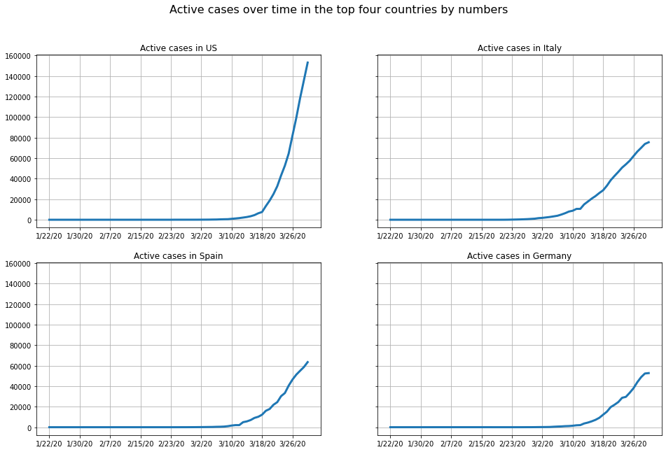

As of 27.03, US has surpassed Italy in number of active cases and China in number of total positives.  
US curve of active cases has grown dramatically in the last two weeks.  
Italy started a strong growth of cases around the carnival festivities in the third week of February whereas Germany's and Spain's curves of active cases started to go up at a fast pace around two weeks after.  
Question: Why the curve in US took momentum in such a short timeframe in comparison to Italy, Germany and Spain? Might it be related to number and timing of tests?  
As of 31.03, the growth of the active cases curves for Italy and Germany is showing signs of slowing down and flattening.

We compare the curves above with the one from China, the country with the most reported cases so far but with a declining number of new positive cases.  
We added also the graph from South Korea where the active cases are starting to drop since mif March.  
In both countries the peak of active cases shows in the graphs around a month since the curve started to increase at a fast pace.  
Both countries took strict measures to content the spread of the virus including lockdowns of hotspots, social distancing, self-isolation and closing of public places and schools. In addition, in South Korea, a massive testing campaign was done to identify and traces cases in the earlier stages and limit the spread.

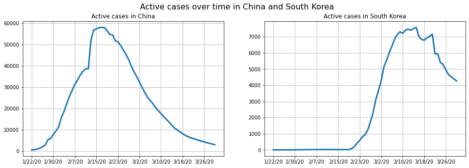